# Fakultät für Physik

## Physikalisches Praktikum P2 für Studierende der Physik

Versuch P2-16, 17, 18 (Stand: April 2023)

[Raum F1-29](http://www-ekp.physik.uni-karlsruhe.de/~simonis/praktikum/layoutobjekte/Lageplan_P1.png)

Name: Stier Vorname: Jonah E-Mail: uifed@student.kit.edu

\begin{equation*} \begin{split} &\\ &\\ \end{split} \end{equation*}

Name: Mutter Vorname: Raphael E-Mail: unodw@student.kit.edu

\begin{equation*} \begin{split} &\\ &\\ &\\ \end{split} \end{equation*}

Gruppennummer: Mo31

\begin{equation*} \begin{split} &\\ &\\ &\\ \end{split} \end{equation*}

Betreuer: Arian Vosoghi Marand

\begin{equation*} \begin{split} &\\ &\\ &\\ \end{split} \end{equation*}

Versuch durchgeführt am: 22.04.2024

**Beanstandungen:**

\begin{equation*} \begin{split} &\\ &\\ &\\ &\\ &\\ &\\ &\\ &\\ &\\ &\\ \end{split} %\text{\vspace{10cm}} \end{equation*}

Testiert am: __________________ Vermerk: __________________

# Laser-Optik, Teil A

## Motivation

Mit diesem Versuch lernen Sie die grundlegenden Konzepte von [Lasern](https://de.wikipedia.org/wiki/Laser) und ihrer Anwendung in der modernen Physik kennen. Darüber hinaus können Sie Ihr Verständnis der Eigenschaften von Licht und elektromagnetischen Wellen vertiefen.

Das Laser (*light amplification by stimulated emission of radiation*)-Prinzip beruht auf der 1916 von Albert Einstein erstmals beschriebenen stimulierten Emission elektromagnetischer Wellen. Der erste funktionsfähige Maser –noch im Mikrowellenbereich– wurde 1954 von [Charles Townes](https://de.wikipedia.org/wiki/Charles_H._Townes) realisiert. Die Übertragung des Maser-Prinzips zu den kürzeren Wellenlängen des sichtbaren Lichts gelang [Theodore Maiman](https://de.wikipedia.org/wiki/Theodore_Maiman) 1960 mit dem ersten Rubinlaser. Seitdem wurden die Eigenschaften und Leistungsfähigkeit von Lasern kontinuierlich erweitert und verbessert. Laser sind eine brillante Quelle für [hoch-kohärentes Licht](https://de.wikipedia.org/wiki/Koh%C3%A4renzl%C3%A4nge). Sie sind damit Wegbereiter für interferometrische Längenmessungen oder die Untersuchung quantenmechanisch verschränkter Zustände. Sie finden Anwendung beim Nachweis von [Gravitationswellen](https://de.wikipedia.org/wiki/Gravitationswelle) sowie bei der Erzeugung von Qbits im [Quantencomputing](https://de.wikipedia.org/wiki/Quantencomputer). Von der Kommunikation und Datenspeicherung bis hin zur Materialbearbeitung und Medizin sind Laser zu wichtigen Werkzeugen in Wissenschaft und Technik geworden.

## Lernziele

Wir listen im Folgenden die wichtigsten **Lernziele** auf, die wir Ihnen mit dem Versuch **Laser-Optik, Teil A** vermitteln möchten:

- Sie machen sich mit dem Funktionsprinzip und den Eigenschaften eines Lasers vertraut.
- Sie üben sich darin optische Bauelemente entlang eines Laserstrahls auszurichten.
- Sie verwenden den Laser als ideale (kohärente) Lichtquelle für verschiedene Beugungs- und Interferenzmessungen.
- Sie erstellen eine holographische Abbildung.
- Sie erfahren, wie Laser in modernen Forschungsfeldern, so wie der Kommunikation, der medizinischen Diagnostik und der Materialbearbeitung eingesetzt werden.

## Versuchsaufbau

Auf einer optischen Bank können neben einem $\mathrm{He}$-$\mathrm{Ne}$-Laser mehrere optische Bauelemente montiert werden. Zur Verfügung stehen mehrere Spalte, Blenden und Gitter, wie in der folgenden Photographie abgebildet: ([Link](https://git.scc.kit.edu/etp-lehre/p2-for-students/-/raw/main/Laser-Optik_Teil_A/figures/LaserA.jpg))

[figure not shown]

Für die verschiedenen Versuchsteile stehen Ihnen die folgenden Geräte und Materialien zur Verfügung:

- Ein offener $\mathrm{He}$-$\mathrm{Ne}$-Laser, (Spindler & Hoyer Typ 500, zu Demonstrationszwecken). Der Laser hat eine Leistung von $P=2\,\mathrm{mW}$ bei einer Wellenlänge von $\lambda=632,8\,\mathrm{nm}$. Er verfügt über ein Entladungsrohr, (um eine horizontale Achse gekippte) Brewster-Fenster, zwei Resonatorspiegel (mit Reflexionsgraden $R=99,7\,\%$ und $R=98\,\%$), entsprechende Schutzkappen, ein Versorgungsgerät, Filterkappen und ein Justierkreuz. Der Bereich zwischen Spiegel und Brewster-Fenster ist für Experimente zugänglich. **Dieser Aufbau ist nur einfach vorhanden!**
- $\mathrm{He}$-$\mathrm{Ne}$-Laser, Polytec PL-610P, mit einer Leistung von $P=5\,\mathrm{mW}$ (in geschlossener Bauform mit integriertem Netzteil, für polarisiertes Licht, siehe Bild). Ein solcher Laser befindet sich an allen Plätzen.
- Ein Experimentiertisch (mit $3\,\mathrm{m}$-Zeißschiene), diverse Reiter und Verschiebereiter.
- Ein kleinflächiger Lichtdetektor mit Phototransistor, in einem Gehäuse mit Anschlussbuchsen für eine Betriebsgleichspannung zwischen $9-15\,\mathrm{V}$ und ein entsprechendes Messinstrument. Dieser Lichtdetektor besitzt, durch eine entsprechende Frontlinse, eine ausgeprägte Richtcharakteristik. Er ist sehr lichtempfindlich und leicht übersteuerbar. Er ist deshalb nur für geringe Lichtintensität vorgesehen.
- Ein Netzgerät ($2\times15\,\mathrm{V}$), für den Phototransistor. Sie können $1\times15\,\mathrm{V}$ sowohl an der roten als auch an der schwarzen Buchse abgreifen.
- Ein großflächiger Lichtdetektor mit $\mathrm{Si}$-Photoelement (Durchmesser der Photodiode $d=12\,\mathrm{mm}$). Betreiben Sie diesen Lichtdetektor nur im Elementbetrieb, d.h. schließen Sie ihn ohne Betriebsspannung direkt an ein Spannungs- oder Strommessgerät an.
- Vielfachmessinstrument (Metex 3800 mit digitaler LCD-Anzeige, alle benötigten Messbereiche verfügbar), mit gleichem Innenwiderstand für alle Gleichstrombereiche. Daher ist die Anzeige auch über die Bereichsgrenzen hinaus proportional zur Intensität im $\mathrm{Si}$-Photoelement; Achtung: Verwenden Sie für die Schalterstellung des $20\,\mathrm{A}$-Bereichs die spezielle $20\,\mathrm{A}$-Buchse, die allgemeine $\mathrm{A}$-Buchse ist nur für Messungen im $20\,\mu\mathrm{A}$-Bereich vorgesehen.
- Ein Strahlaufweitungssystem, bestehend aus einer Mikrobank auf einem Stift. Auf der Mikrobank befinden sich in entsprechenden Haltern spezielle, für die Laserlicht-Wellenlänge korrigierte Linsen mit Brennweiten von $f_{1}=10\,\mathrm{mm}$ und $f_{2}=150\,\mathrm{mm}$ im Abstand $f_{1}+f_{2}$, als [telezentrisches System](https://de.wikipedia.org/wiki/Telezentrisches_Objektiv).
- Ein Justieraufbau, bestehend aus einer Mikrobank auf einem Stift. Auf der Mikrobank befinden sich drei verschiebbare $25\,\mathrm{mm}$-Bauteil-Halter, von denen mindestens einer transversal justierbar ist.
- Diverse Halter für Linsen, Blenden, Hologramme und sonstiges.
- Ein Eisen-Schirm mit Haftmagneten, um Papier daran zu befestigen, ein Planspiegel auf einem Stift mit Kugelgelenk.
- Eine Mattscheibe (in einem Halter auf einem Stift), eine Glasplatte (in einem Halter, drehbar um die horizontale Achse, mit Winkelskala).
- Ein Polarisationsfilter (mit Durchmesser $d=10\,\mathrm{cm}$, auf einem Stift, drehbar, mit Winkelskala). **Diesen sollten Sie nicht im unaufgeweiten Strahl benutzen!**
- Ein Hologramm ($8,5\,\mathrm{cm}\times10\,\mathrm{cm}$), in einem Halter auf einem Stift.
- Im Dia-Format:
  - Strichgitter mit $570\,\mathrm{Strichen/mm}$,
  - Kreuzgitter mit $13,4\,\mathrm{Strichen/mm}\times15\,\mathrm{Strichen/mm}$,
  - Kreuzgitter mit $2,6\,\mathrm{Strichen/mm}\times3,8\,\mathrm{Strichen/mm}$;
  - Scheibenblende mit Durchmessern $d=1;\,1.5;\,2\,\mathrm{mm}$.
- In $25\,\mathrm{mm}$-Fassungen:
  - Strichgitter mit $100\,\mathrm{Strichen/cm}$,
  - Kreuz- und Wabengitter (ohne Dimensionsangabe),
  - Beugungsordnungsblende mit 5 speziellen Öffnungen,
  - Beugungskante,
  - Lochblende, mit Durchmesser $d=1\,\mathrm{mm}$,
  - Scheibenblende, mit Durchmesser $d=1\,\mathrm{mm}$,
  - Beugungssteg mit Breite $b=0,3\,\mathrm{mm}$,
  - Verschiedene Spalten mit Breite $b=0,2\,\mathrm{mm}$, $0,3\,\mathrm{mm}$ und $0,4\,\mathrm{mm}$.
  - Doppelspalte mit den folgenden Spaltbreiten ($b$) und Abständen ($\ell$): $b=0,25\,\mathrm{mm}$, $\ell=0,5\,\mathrm{mm}$ und $b=0,25\,\mathrm{mm}$, $\ell=0,75\,\mathrm{mm}$,
  - Dreifachspalt mit Spaltbreite $b=0,25\,\mathrm{mm}$ und Abstand $\ell=0,5\,\mathrm{mm}$,
  - Vierfachspalt mit Spaltbreite $b=0,2\,\mathrm{mm}$ und Abstand $\ell=0,3\,\mathrm{mm}$,
  - Einstellspalt, Irisblende, Polarisationsfilter ohne Skala.
  - Linsen mit verschiedenen Brennweiten zwischen $10-150\,\mathrm{mm}$.
- Tischlampe, Taschenlampe, Maßband, Reinigungsutensilien.

## Wichtige Hinweise

- Bei diesem Versuch arbeiten Sie mit einem Laser, der entsprechend **gefährlich für Ihre Augen** sein kann. Gehen Sie daher **vorsichtig und verantwortungsbewusst** mit dem Laser um und halten Sie sich an die Anweisungen des/der Tutor:in.
- Achten Sie darauf, dass alle Personen im Raum bei der Durchführung des Versuchs eine **Schutzbrille** tragen.
- Vermeiden Sie direkten Blickkontakt mit dem Laserstrahl und richten Sie ihn niemals auf andere Personen. Bleiben Sie beim Experimentieren in der Regel stehen, mit den Augen also weit oberhalb der Strahlhöhe.
- Stellen Sie sicher, dass die Laserleistung und -frequenz auf die vorgesehenen Werte eingestellt sind und überprüfen Sie dies regelmäßig während des Experiments.
- Beachten Sie, dass der Laserstrahl bei falscher Handhabung Schäden an optischen Elementen verursachen kann. Verwenden Sie nur die bereitgestellten optischen Elemente und reinigen Sie sie nur mit geeigneten Materialien.
- Vor dem Einschalten des Lasers müssen alle Geräte sorgfältig aufgebaut und justiert werden. Führen Sie diese Schritte **erst nach Rücksprache mit dem/der Tutor:in** durch.

```python
import matplotlib.pyplot as plt
import numpy as np
import uncertainties as u
```

## Durchführung

### **Aufgabe 1: Bestimmung des [Brewsterwinkels](https://de.wikipedia.org/wiki/Brewster-Winkel)**

Bei Gaslasern wird das [Entladungsrohr](https://de.wikipedia.org/wiki/Gasentladungsr%C3%B6hre) meist mit "Brewster-Fenstern" abgeschlossen. Überlegen Sie sich den Sinn dafür und demonstrieren Sie die Notwendigkeit. Gehen Sie dabei wie folgt vor:

Montieren Sie einen drehbaren Plattenhalter mit planparalleler, sorgfältig geputzter Glasscheibe vor den Laser, verändern Sie den Einfallswinkel und beobachten Sie die Strahlintensität. Bestimmen Sie den Brewsterwinkel, und daraus den Brechungsindex $n$ des Glases. Sie können das Minimum der Reflexion ohne Intensitätsmessung an der Zimmerdecke beobachten. Für die Beobachtung des Maximums der Transmission können Sie z.B. das Si-Photoelement mit geeignetem Messinstrument benutzen. Ein solches Vorgehen ist aber ungenauer als die Beobachtung des Minimums. Diskutieren Sie warum dies so ist.

Wenn Licht auf eine Grenzfläche mit Übergang von einem optisch dünneren auf ein dichteres Medium trifft und Summe des Einfallwinkels $\alpha$ und des Ausfallwinkels $\beta$, $\alpha + \beta =90^\circ$, beträgt so wird kein parallel zur Einfallebene polarisiertes Licht reflektiert. Das folgt aus $\rho_p = \frac{tan(\alpha-\beta)}{tan(\alpha+\beta)}$. Es ist zu sehen, dass die Reflektivität für die E-feld Komponente parallel zur Einfallsebene für $\alpha + \beta = 90°$ gegen null geht. Also steigt der Polarisationsgrad des transmitierten Lichtes.

Wird ein Gasentladungslaser mit Brewsterflächen abgeschlossen bietet das zwei Vorteile:

- Das p-polarisierte Licht wird ohne Reflektionsverluste durchgelassen
- Da das s-polarisierte Licht teilweise aus den Strahlengang reflektiert wird stellt sich die Polarisation des Lasers in Richtung des p-polarisirten Lichtes ein, aufgrund der positiven Rückkopplung

Mögliche Gründe für die Ungenauigkeit:

- Einflüsse auf die Leitfähigkeit der Diode aufgrund von Streulicht
- Geringere relative Änderung der Intensität

Die Messungen für die Position der Vorrichtung betrugen $124°$ und $121°$.

Daraus ergibt sich ein Brewsterwinkel von $34°$ und $31°$

### **Aufgabe 2: Beugung an Spalt, Steg, Kreisloch, Scheibenblende und Kante**

**2.1:** Bestimmen Sie aus der Lage der Beugungsmaxima und -minima die nur ungefähr angegebenen Breiten ($b_{1}\approx 0,2\,\mathrm{mm}$ und $b_{2}\approx 0,3\,\mathrm{mm}$) der beiden Spalten.

**2.2:** Vergleichen Sie die Beugungsfigur eines gleichbreiten Steges mit der des entsprechenden Spalts ([Babinetsches Theorem](https://de.wikipedia.org/wiki/Babinetsches_Prinzip)).

**2.3:** Betrachten Sie die Beugungsbilder einer Kreisöffnung, einer gleichgroßen Kreisscheibe sowie einer Kante. Diskutieren Sie warum die Mitte der Beugungsfigur (der Poisson-Fleck) einer Scheibenblende stets hell ist.

**2.4:** Bestimmen Sie aus seiner Beugungsfigur den Durchmesser eines Haares. Vergleichen Sie das Ergebnis mit dem einer Messung mit Mikrometerschraube.

**2.1**

Die Lage der Maxima für den Einzespalt ist allgemein durch:

$\sin(\phi_{min}) = \pm (n+1/2)\frac{\lambda}{D}$

Desweiteren gilt für den Abstand x vom Zentrum des Schirmes:

$\tan(\phi_{min}) = \frac{x}{d}$

Mithilfe der Kleinwinkelnäherung für $\phi_{min}$ folgt:

$x_{max} = \frac{(n+1/2)\,\lambda\,d}{D},\, n\in\mathbb{N}$

```python
import numpy as np
import kafe2
import matplotlib.pyplot as plt
from uncertainties import ufloat

d = ufloat(1.5,0.01)
lrot = 632.8*10**(-9)

def x(n,alpha):
    return (n+1/2)*lrot*alpha

def get_D(alpha):
    return d/alpha
```

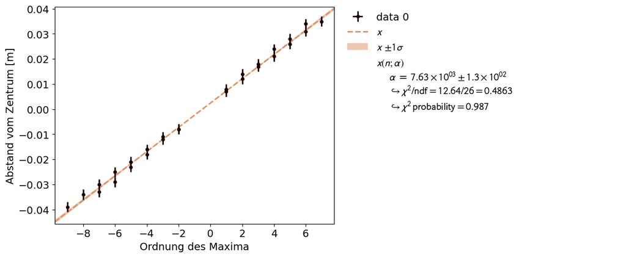

```
Der ermittelte Wert für die Spaltbreite liegt bei: D = 0.0001965+/-0.0000035 m
```

```python
dists_2_r = [0.008, 0.014, 0.018, 0.024, 0.028, 0.034]
dists_2_l = [-0.008, -0.012, -0.018, -0.023, -0.029, -0.033]

dists_3_r = [0.007, 0.012, 0.017, 0.021, 0.026, 0.031, 0.035]
dists_3_l = [-0.008, -0.011, -0.016, -0.021, -0.025, -0.030, -0.034, -0.039]

ns = [n for n in range(1,len(dists_2_r)+1)]
ns_neg = [-n for n in range(2,len(dists_2_r)+2)]
nss = [n for n in range(1,len(dists_3_r)+1)] + [-n for n in range(2,len(dists_3_l)+2)]


Fit=kafe2.XYContainer(ns+ns_neg+nss,dists_2_r+dists_2_l+dists_3_r+dists_3_l)
Fit.add_error(axis='y',err_val=0.002)

Fit.axis_labels=['Ordnung des Maxima','Abstand vom Zentrum [m]']

Fit2=kafe2.Fit(Fit,x)
Fit2.do_fit()
alpha = ufloat(Fit2.parameter_values[0],Fit2.parameter_errors[0])

Fit=kafe2.Plot(Fit2)
Fit.plot()
plt.show()
print("Der ermittelte Wert für die Spaltbreite liegt bei: D =",get_D(alpha),"m")
```

Der im Experminet ermittelte Wert für die Dicke des Spaltes mit der Angabe $D \approx 0.2mm$ beträgt damit

$D_{Interferenz} = 0.1965\pm 0.0035\,mm$

Damit liegt das Ergebniss sehr nahe an unserer Erwartung.

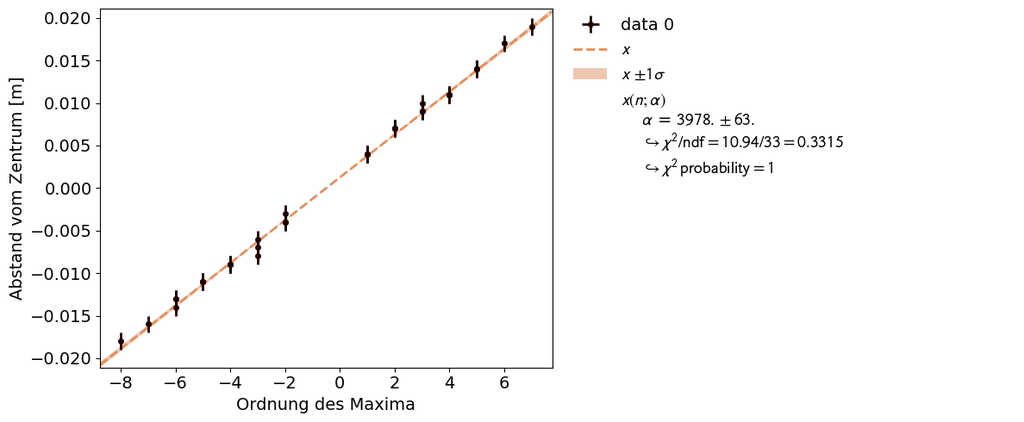

```
Der ermittelte Wert für die Spaltbreite liegt bei: a = 0.000279+/-0.000004 m
```

```python
dist_spalt_r = [0.004,0.007,0.009,0.011,0.014,0.017,0.019]
dist_spalt_l = [-0.003,-0.006,-0.009,-0.011,-0.013,-0.016,-0.018]

dist_spalt_r_2 = [0.004,0.007,0.009,0.011,0.014]
dist_spalt_l_2 = [-0.004,-0.007,-0.009,-0.011,-0.014]

dist_spalt_r_3 = [0.004,0.007,0.010,0.011,0.014]
dist_spalt_l_3 = [-0.004,-0.008,-0.009,-0.011,-0.013]

all = [dist_spalt_r,dist_spalt_l,dist_spalt_r_2,dist_spalt_l_2,dist_spalt_r_3,dist_spalt_l_3]

def x_g(n,alpha):
    return n*lrot*alpha

nss = [[n for n in range(1,len(element)+1)] for element in all]
nss_neg = [[-n for n in range(2,len(element)+2)] for element in all]
d = 1.11
nss = nss[0]+nss_neg[1]+nss[2]+nss_neg[3]+nss[4]+nss_neg[5]
Fit=kafe2.XYContainer(nss,all[0]+all[1]+all[2]+all[3]+all[4]+all[5])
Fit.add_error(axis='y',err_val=0.001)

Fit.axis_labels=['Ordnung des Maxima','Abstand vom Zentrum [m]']

Fit2=kafe2.Fit(Fit,x)
Fit2.do_fit()


Fit=kafe2.Plot(Fit2)
Fit.plot()
plt.show()
alpha = ufloat(Fit2.parameter_values[0],Fit2.parameter_errors[0])
print("Der ermittelte Wert für die Spaltbreite liegt bei: a =",get_D(alpha),"m")
```

AUch hier liegt das Ergebniss im bereich unserer Erwartungen und es liegt eine hohe $\chi^2$-Wahrscheinlichkeit vor.

**2.2 Babinetsche Theorem**

Es ist zu sehen, dass die Beugungsbilder von Spalt und Steg annähernd gleich sind. Eben jenes besagt das Babinetsche Theorem. Demnach sind die Beugungsbilder zweier zueinnander komplimentären Beugungsflächen identisch unter Abzug des auf geometrischem Wege ankommenden Lichts.

Die Abweichungen in der Messung lassen sich mit der schlechten Ablesegenauigkeit selbst mit Millimeterpapier zurückführen. Die Lage der Maxima war aufgrund der Laserbrillen und der somit deutlich reduzierten Intensität schlecht auszumachen und konnten mangels Geschicks auch nicht immer sauber mit dem Stift markiert werden.

Weiter sind Einflüsse wie das leichte Verdrehen des Schirms nicht auszuschließen. Zudem konnten um das Hauptmaximum die Nebenmaxima nicht immer akkurat bestimmt werden.

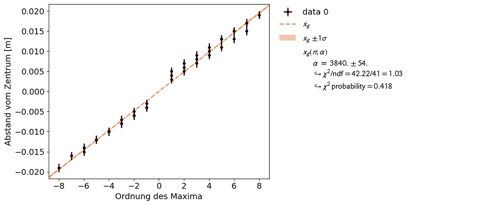

```
Der ermittelte Wert für die Breite des Steges liegt bei: D = 0.000292+/-0.000005 m
```

```python
dist_steg_r = [0.004,0.006,0.008,0.010,0.013,0.015,0.017,0.019]
dist_steg_l = [-0.004,-0.006,-0.008,-0.010,-0.012,-0.015]

dist_steg_2_r = [0.003,0.005,0.007,0.009,0.011,0.013,0.015]
dist_steg_2_l =[-0.004,-0.006,-0.008,-0.010,-0.012,-0.014,-0.016,-0.019]

dist_steg_3_r = [0.005,0.007,0.009,0.011,0.013,0.015,0.017]
dist_steg_3_l = [-0.003,-0.005,-0.007,-0.010,-0.012,-0.014]

all2 = [dist_steg_r,dist_steg_l,dist_steg_2_r,dist_steg_2_l,dist_steg_3_r,dist_steg_3_l]

nss = [[n for n in range(1,len(element)+1)] for element in all2]
nss_neg = [[-n for n in range(1,len(element)+1)] for element in all2]
d = ufloat(1.12,0.01)
nss = nss[0]+nss_neg[1]+nss[2]+nss_neg[3]+nss[4]+nss_neg[5]
Fit=kafe2.XYContainer(nss,all2[0]+all2[1]+all2[2]+all2[3]+all2[4]+all2[5])
Fit.add_error(axis='y',err_val=0.001)

Fit.axis_labels=['Ordnung des Maxima','Abstand vom Zentrum [m]']

Fit2=kafe2.Fit(Fit,x_g)
Fit2.do_fit()

Fit=kafe2.Plot(Fit2)
Fit.plot()
plt.show()
alpha = ufloat(Fit2.parameter_values[0],Fit2.parameter_errors[0])
print("Der ermittelte Wert für die Breite des Steges liegt bei: D =",get_D(alpha),"m")
```

Wie durch das Babinetsche-Theorem erwartet, erhält man für den Steg mit $D \approx 0.3mm$ sein sehr ähnliches Interferenzmuster und einen Wert für die Stegbreite von $D = 0.292\pm0.005\,mm$

**2.3:**

Bei der Lochblende trat aufgrund des großen Durchmessers keine auffällige Beugung auf. Es war ein Punkt auf dem Schirm zu sehen. Bei der Scheibenblende könnte man nun erwarten, dass ein kreisförmiger Schatten auftritt jedoch war ein etwas weniger scharfer Punkt als bei der Lochblende zu sehen. Es war zu sehen, dass Interferenzmuster auftraten, jedoch waren keine Maxima auszumachen. Der helle Fleck inn der Mitte liegt am Wellencharakter von Licht, da die in der Mitte zusammenlaufenden Wellen keinen Gangunterschied aufweisen und somit konstruktiv interferieren.

Bei der Kante war ein Lichtpunkt zu erkennen der zur Seite der Kante hin länger wurde. Dies liegt an der Beugung an der Seite der kante wobei nach dem Huygensschen Prinzip jeder Punkt der Welle Ausgangspunkt einer Elementarwelle ist. somit kommt es zu Beugungserscheinungen vergleichbar zum Einzelspalt, mit dem Unterschied, dass an der anderen Seite keine Beugung stattfindet. im Versuch ließen sich aufgrund er hohen Intensität des Lasers kein Muster ausmachen, es war nur ein strich zu sehen. Das Bild (Abb 2.3.3) zeigt die Entstandene Beugungserscheinung nicht.

[figure not shown]

Abb 2.3.1 Photo der Intensitätsverteilung der Lochblende

[figure not shown]

Abb 2.3.2 Photo der Intensitätsverteilung der Kreisblende

[figure not shown]

Abb 2.3.3 Photo der Intensitätsverteilung der Beungungskante

**2.4:**

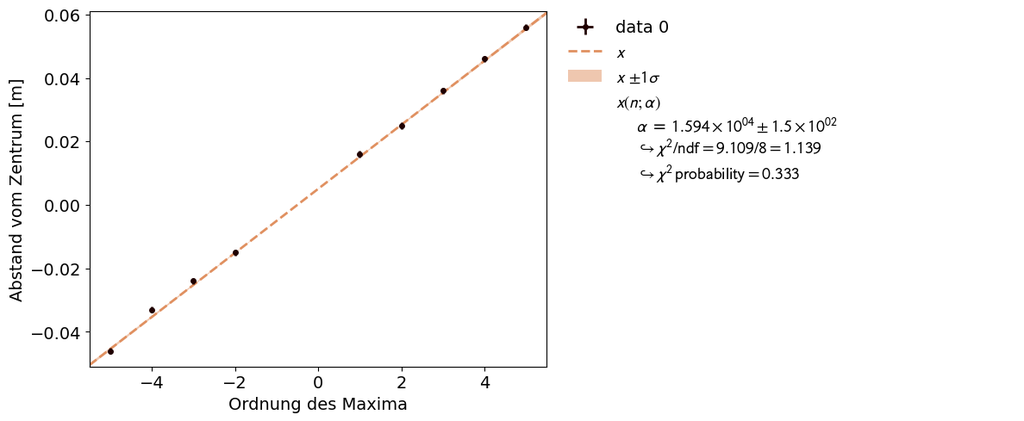

```
Der ermittelte Wert für die Haardicke liegt bei: D = (6.96+/-0.09)e-05 m
```

```python
dists_haar_r = [0.016, 0.025, 0.036, 0.046, 0.056]
dists_haar_l = [-0.015, -0.024,-0.033, -0.046]

d = ufloat(1.11,0.01)
nss = [n for n in range(1,len(dists_haar_r)+1)] + [-n for n in range(2,len(dists_haar_l)+2)]
Fit=kafe2.XYContainer(nss,dists_haar_r+dists_haar_l)
Fit.add_error(axis='y',err_val=0.001)

Fit.axis_labels=['Ordnung des Maxima','Abstand vom Zentrum [m]']

Fit2=kafe2.Fit(Fit,x)
Fit2.do_fit()

Fit=kafe2.Plot(Fit2)
Fit.plot()
plt.show()
alpha = ufloat(Fit2.parameter_values[0],Fit2.parameter_errors[0])
print("Der ermittelte Wert für die Haardicke liegt bei: D =",get_D(alpha),"m")
```

Damit liegt die über die Interferenz ermittelte Haardicke

$D_{Interferenz} = 69.6\pm0.9 \,\mu m$

relativ nahe bei dem durch die Millimeterschraube festgeselltem Wert von

$D_{Schraube} = 60\pm5 \,\mu m$

### **Aufgabe 3: Beugung an Mehrfachspalten und Gittern**

**3.1:** Bestimmen Sie die Spaltbreite $b$ und den -abstand ($\ell$) eines der Doppelspalte aus dessen Beugungsbild.

**3.2:** Machen Sie eine Voraussage und beobachten Sie dann:

1. wie sich das Beugungsbild bei Verwendung eines zweiten Doppelspalts ändert; und
2. wie sich das Beugungsbild des Dreifachspalts von dem des Doppelspalts (jeweils mit der Spaltbreite $b=0,25\,\mathrm{mm}$ und dem Spaltabstand $\ell=0,5\,\mathrm{mm}$) unterscheidet.

**3.3:** Bestimmen Sie die Gitterkonstante $g$ eines der Strichgitter. Beobachten Sie das Beugungsbild. Diskutieren Sie welche Rolle dabei die Ausleuchtung spielt.

**3.4:** Beobachten Sie Beugungsbilder von Kreuz- und Wabengittern.

**3.1**

Analog zur Betrachtung des Einzelspaltes gilt für die Position der Maxima des Doppelspaltes und des Gitters:

$x_{max} = \frac{n\,d\,\lambda}{a},\, n\in\mathbb{N}$

wobei $a$ der Spaltabstand ist.

Hier wurde die Substitution $\alpha = \frac{d}{a}$ verwendet.

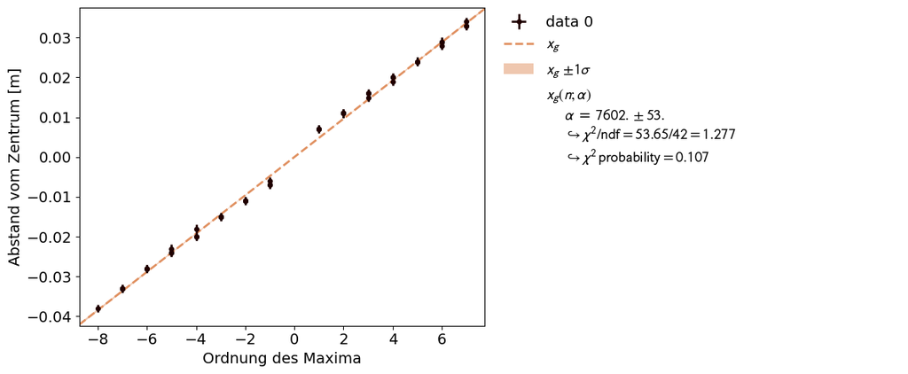

```
Der ermittelte Wert für den Spaltabstand beträgt: l = 0.0001855+/-0.0000018 m
```

```python
dists_doppel_1_r = [0.007, 0.011, 0.015, 0.02, 0.024, 0.028, 0.034]
dists_doppel_1_l = [-0.007, -0.011, -0.015, -0.02, -0.024, -0.028, -0.033]

dists_doppel_2_r = [0.007, 0.011, 0.016, 0.019, 0.024, 0.029, 0.033]
dists_doppel_2_l = [-0.007, -0.011, -0.015, -0.02, -0.024, -0.028, -0.033, -0.038]

dists_doppel_3_r = [0.007, 0.011, 0.016, 0.02, 0.024, 0.029, 0.033]
dists_doppel_3_l = [-0.006, -0.011, -0.015, -0.018, -0.023, -0.028, -0.033]

d = ufloat(1.41,0.01)

all3 = [dists_doppel_1_r,dists_doppel_1_l,dists_doppel_2_r,dists_doppel_2_l,dists_doppel_3_r,dists_doppel_3_l]

nss = [[n for n in range(1,len(element)+1)] for element in all3]
nss_neg = [[-n for n in range(1,len(element)+1)] for element in all3]
nss = nss[0]+nss_neg[1]+nss[2]+nss_neg[3]+nss[4]+nss_neg[5]
Fit=kafe2.XYContainer(nss,all3[0]+all3[1]+all3[2]+all3[3]+all3[4]+all3[5])
Fit.add_error(axis='y',err_val=0.001)

Fit.axis_labels=['Ordnung des Maxima','Abstand vom Zentrum [m]']

Fit2=kafe2.Fit(Fit,x_g)
Fit2.do_fit()

Fit=kafe2.Plot(Fit2)
Fit.plot()
plt.show()
alpha = ufloat(Fit2.parameter_values[0],Fit2.parameter_errors[0])
print("Der ermittelte Wert für den Spaltabstand beträgt: l =",get_D(alpha),"m")
```

Die Spaltbreite konnte nicht ermittelt werden, da die Einhüllende im Interferenzmuster nicht klar zu erkennen war.

**3.2**

In folgenden wird die Kleinwinkelnäherung verwendet, da mit ihr qualitativ ausreichend richtige Aussagen erreicht werden können:

Für den Doppelspalt unter Anwendung der Kleinwinkelnäherung, $\frac{\Delta s}{b} = \frac{\Delta x}{A}$ gilt $\Delta x =\frac{A \Delta s}{b}$. Also ist der Abstand der Maxima umgekehrt proportional zum Spaltabstand.

Also ist zu erwarten, dass bei dem zweiten Doppelspalt mit größerem Spaltabstand die Maxima näher zusammenliegen. Jedoch wurde in der Auswertung klar, dass der zweite, eigentlich mit 0.25mm/0.75mm angegebene Spalt vermutlich falsch einsortiert war, da sich das Interferenzmuster nicht von dem ursprünglichen Spalt unterscheidet.

Beim Dreifachspalt fallen bei gleichem Spaltabstand die Maxima mit den Maxima des Doppelspalts zusammen. Demnach unterscheidet sich das Muster nur durch die Nebenmaxima und die Minima. Die Minima und die Nebenmaxima sind jedoch nicht sonderlich gut auszumachen. Die Beobachtungen stimmen mit der Vermutung überein.

Da die Spaltbreite bei allen drei Spalten gleich groß ist und demnach auch die Einhüllende der Intensitätsverteilung gleich groß ist wird hier nicht verglichen. Es ist jedoch angemerkt das diese mit dem Handy und mit den Augen nur schwer wahrnehmbar war.

[figure not shown]

Abb 3.2.1 Doppelspalt 0.25mm/0.5mm

[figure not shown]

Abb 3.2.1 Doppelspalt 0.25mm/0.75mm

[figure not shown]

Abb 3.2.1 Dreifachspalt 0.25mm/0.5mm

**3.3**

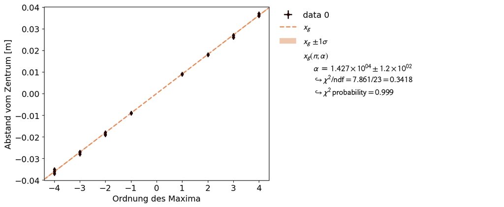

```
Der ermittelte Wert für die Gitterkonstante beträgt: g = (7.78+/-0.10)e-05 m
```

```python
dists_gitter_u1 =[0.009, 0.018, 0.027, 0.036]
dists_gitter_o1 =[-0.009, -0.019, -0.027, -0.035]

dists_gitter_u2 = [0.009, 0.018,0.026, 0.037]
dists_gitter_o2 = [-0.009, -0.019, -0.028, -0.036]

dists_gitter_u3 =[0.009, 0.018, 0.026, 0.036]
dists_gitter_o3 =[-0.009, -0.018, -0.027, -0.037]


all4 = [dists_gitter_o1,dists_gitter_o2,dists_gitter_u1,dists_gitter_u2,dists_gitter_u3,dists_gitter_o3]

nss = [[n for n in range(1,len(element)+1)] for element in all4]
nss_neg = [[-n for n in range(1,len(element)+1)] for element in all4]
nss = nss_neg[0]+nss_neg[1]+nss[2]+nss[3]+nss[4]+nss_neg[5]
Fit=kafe2.XYContainer(nss,all4[0]+all4[1]+all4[2]+all4[3]+all4[4]+all4[5])
Fit.add_error(axis='y',err_val=0.001)
d = ufloat(1.11,0.01)

Fit.axis_labels=['Ordnung des Maxima','Abstand vom Zentrum [m]']

Fit2=kafe2.Fit(Fit,x_g)
Fit2.do_fit()

Fit=kafe2.Plot(Fit2)
Fit.plot()
plt.show()
alpha = ufloat(Fit2.parameter_values[0],Fit2.parameter_errors[0])
print("Der ermittelte Wert für die Gitterkonstante beträgt: g =",get_D(alpha),"m")
```

**3.4**

Die Gitterkonstante des Kreuzgitters betrug ca. $100\,\frac{1}{cm}$. Es handelt sich dabei um zwei orthogonal angeordnete Beugungsgitter. Erwartungsgemäß ist ein Punktemuster zu sehen das kreuzförmig abnimmt, entsprechend der Überlagerung der Intensitätsverteilung zweier Gitter.

[figure not shown]

Abb 3.4.1 Photo der Intensitätsverteilung des Kreuzgitters

Die Gitterkonstante des Wabengitters ist nicht bekannt. Die Intensitätsverteilung nimmt in sechs "Strahlen" nach außen ab.

[figure not shown]

Abb 3.4.2 Photo der Intensitätsverteilung des Wabengitters

### **Aufgabe 4: Abbildung nichtselbstleuchtender Gegenstände (Abbésche Theorie#Abbe-Limit))**

Zeigen Sie, dass für die Abbildung durchstrahlter Objekte das Beugungsmuster des Lichts eine wichtige Rolle spielt. Gehen Sie dabei wie folgt vor:

Beleuchten Sie, je nach Wahl, ein Waben- oder Strichgitter (mit $100\,\mathrm{Strichen/cm}$) mit parallelem Licht und bilden Sie das Beugungsbild mit Hilfe einer Linse mit $150\,\mathrm{mm}$ Brennweite auf eine Mattscheibe ab. Sie können das Licht zuvor mit Hilfe eines fernen Planspiegels umlenken, so dass Sie die Mattscheibe in Lasernähe neben der optischen Bank positionieren und das Beugungsbild beim Justieren beobachten können.

Eine [Beugungsordnungsblende](https://de.wikipedia.org/wiki/Beugungsscheibchen) in der bildseitigen Brennebene der Linse lässt das Beugungslicht entweder nur 0. oder 0. und 1. Ordnung durch. Da die Beugungsordnungsblende schwierig zu justieren ist, können Sie die 0. Ordnung auch mit einer Scheibenblende (mit Durchmesser $d=1\,\mathrm{mm}$) ausblenden. Beobachten Sie das jeweils auf der Mattscheibe entstehende Bild. Versuchen Sie auch die Beobachtung der folgenden zwei weiteren Fälle: **Nur die 1. Ordnung** oder **nur die 2. Ordnung** passieren die Beugungsordnungsblende. Gitter, Linse und die dazu passende Beugungsordnungsblende werden in einem Justieraufbau montiert, die Beugungsordnungsblende kommt dabei in die nach allen Richtungen transversal zum Strahl verschiebbare Fassung. Zeichnen Sie zu diesem Versuch bei der Vorbereitung den Strahlengang. Wie könnte man den beobachteten Effekt benutzen, um etwa bei einem digitalisiert empfangenen Zeitungsbild das störende Raster verschwinden zu lassen? (Stichwort 'Image Enhancement'; Literatur: Hecht/Zajac)

Die Beugungsordungsblende wurde in ausreichendem Abstand platziert und rotiert bis nur noch die gewünschten Ordnungen zu sehen waren. Eine Scheibenblende wurde nicht verwendet. Es war im Versuch nicht möglich nur die zweite Ordnung abzubilden Die Abbesche-Theorie besagt, dass zur Rekonstruktion des Bildes höhere Ordnungen von Nöten sind. Es handelt sich also um eine Art optische Fourierfilterung. Werden höhere Ordnungen, vergleichbar mit hohen Frequenzen in der herkömmliche Fouriertransformation, der aufgrund der Linse Fouriertransformierten, ausgeblendet, wird die Bildinformation reduziert. Es sollte gezeigt werden, dass zur Rekonstruktion des Gitters die nullte Ordnung keine Informationen bietet. Erst wenn man auch das Muster der ersten Ordnung zulässt, lässt sich das Gitter rekonstruieren, wie in Aufgabe 3 zu sehen. Will man nun das Raster eines digitalisierten Zeitungsbildes verschwinden lassen so kann man die höheren Ordnungen, die das Raster besitzt, durchoptische Filterung gezielt ausblenden.

[figure not shown]

Abb 4.1 Photo der nullten Ordnung des Gitters, hier lässt sich das Gitter nicht rekonstruieren

[figure not shown]

Abb 4.1 Photo der ersten Ordnung des Gitters, hier lässt sich das Gitter wie in A.3 rekonstruieren

### **Aufgabe 5: Holographie**

Reproduzieren Sie ein Hologramm. Vergleichen Sie das reelle mit dem virtuellen Bild.

Weiten Sie den Laserstrahl hierzu jeweils geeignet auf. Überzeugen Sie sich davon, dass Sie wirklich **dreidimensional** beobachten können, d.h. dass sich je nach Beobachtungsposition die Perspektive ändert und zunächst verborgene Details des Hologramms ggf. sichtbar werden. Das reelle Bild kann auf einem Schirm (weißes Papier) aufgefangen werden. Bewegen Sie den Schirm durch das Strahlungsfeld. Zeigen Sie, dass die Information über ein Gegenstandsdetail nicht nur an einer bestimmten Stelle des Hologramms gespeichert ist. Decken Sie hierzu verschiedene Bereiche des zunächst weit ausgeleuchteten Hologramms ab. Dokumentieren und diskutieren Sie Ihre Beobachtungen.

Durch Holographie kann im Gegensatz zur herkömmlichen Photographie ein dreidimensionales Bild erzeugt werden, also entsteht je nach Blickwinkel ein verschiedener Eindruck. Zur Erzeugung eines Hologramms wird ein Strahl kohärentes Licht aufgeweitet und aufgespalten. Einer der beiden Strahlen bestrahlt nun das Objekt und der Andere wird als Referenzwelle mit dem vom Objekt reflektierten Licht auf einer Photoplatte überlagert. Dort interferieren die beiden Strahlen. Wird nun die belichtete Photoplatte erneut mit kohärentem Licht der selben Wellenlänge bestrahlt entsteht ein dreidimensionaler Eindruck da das Licht der belichteten Photoplatte entsprechende Wellenfronten Ausbildet.

Im Versuch wurden zwei Photoplatten bestahlt. Dazu wurde mit einer Linse mit $10\,mm$ Brennweite der Strahl aufgeweitet und so justiert dass möglichst die ganze Photoplatte ausgeleuchtet war. Die erste Photoplatte war lichtundurchlässig. Das reflektierte Licht stellte ein Auto dar. Der Eindruck war nicht sonderlich gut. Die Zweite Photoplatte wurde durchleuchtet und zeigte einen Springer und Holzsteine mit denen "LASER FOCUS" geschrieben war. Dabei war es relativ egal ob ein Teil des Hologramms verdeckt wurde, die Verluste in der Qualität der Abbildung ließen sich auch mit der nicht perfekten Ausleuchtung und Aufweitung erklären. Das liegt daran dass alle Elementarwellen die vom Hologramm ausgehen zur Bildinformation beitragen und bei bedecken nur ein Teil verloren geht

[figure not shown]

Abb 5.1 Photo der Hologramms